# ST_2195 coursework part 2

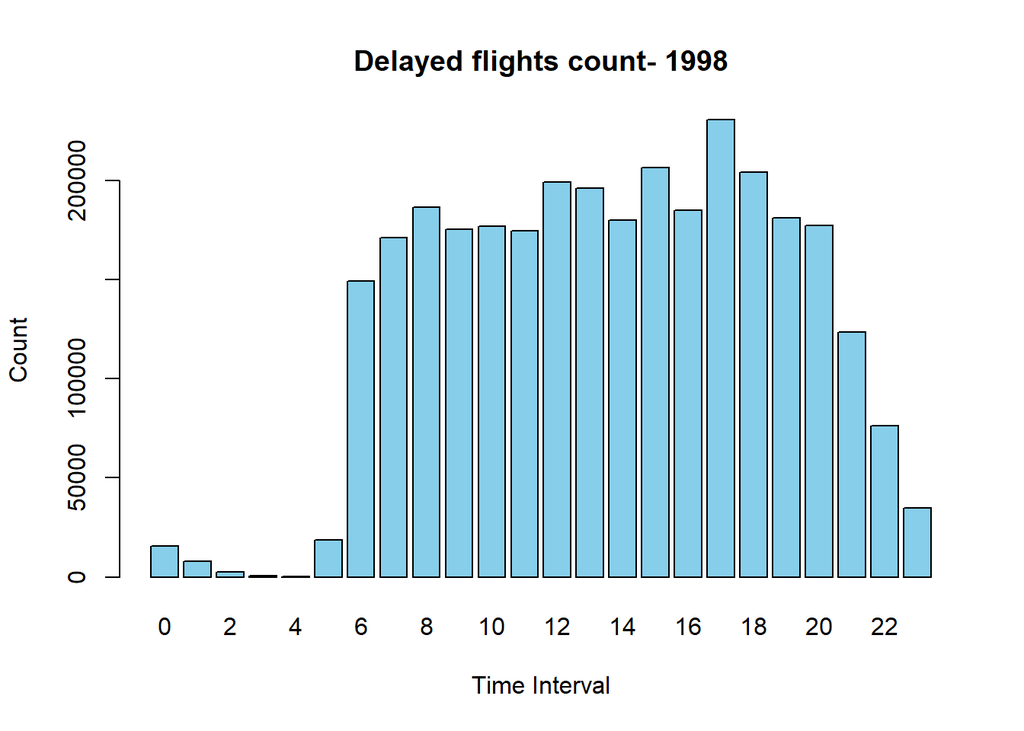

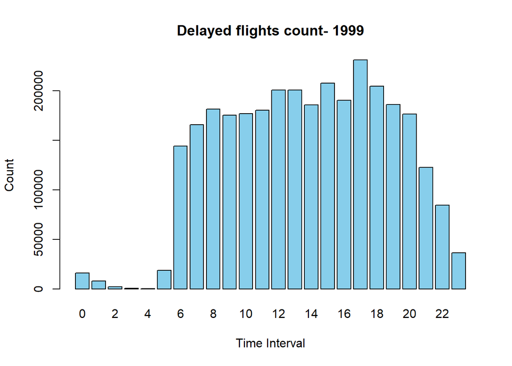

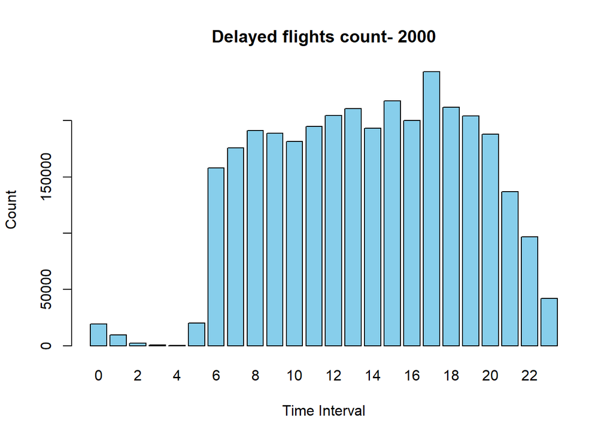

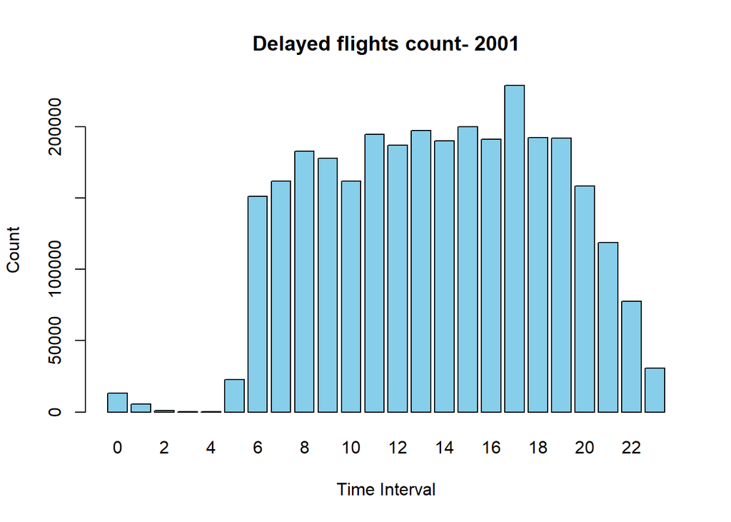

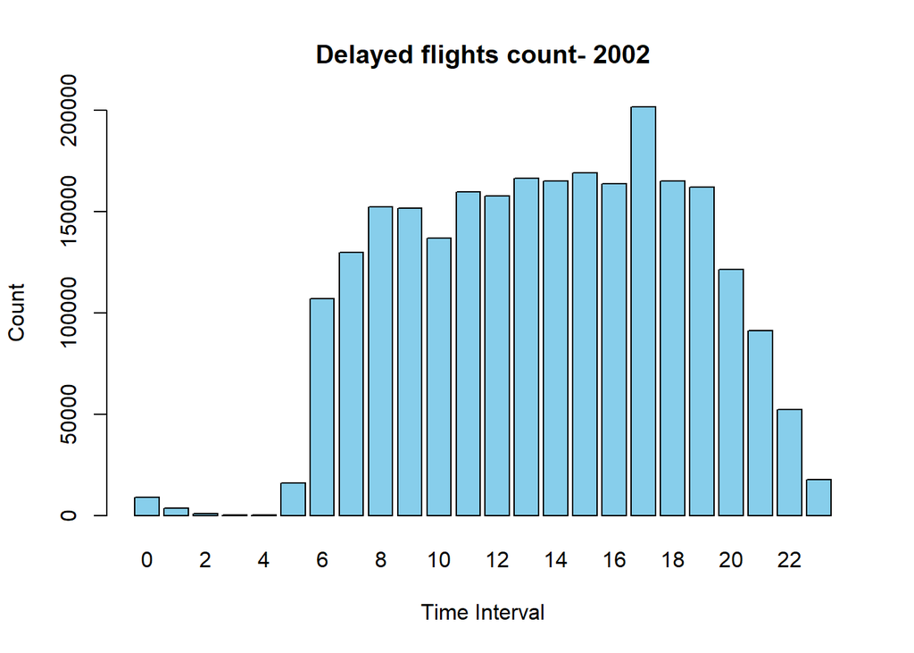

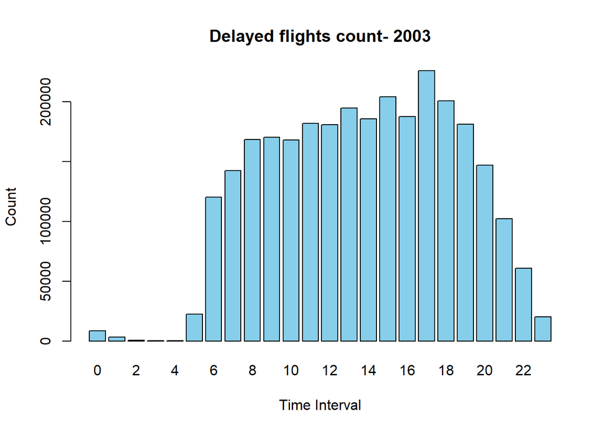

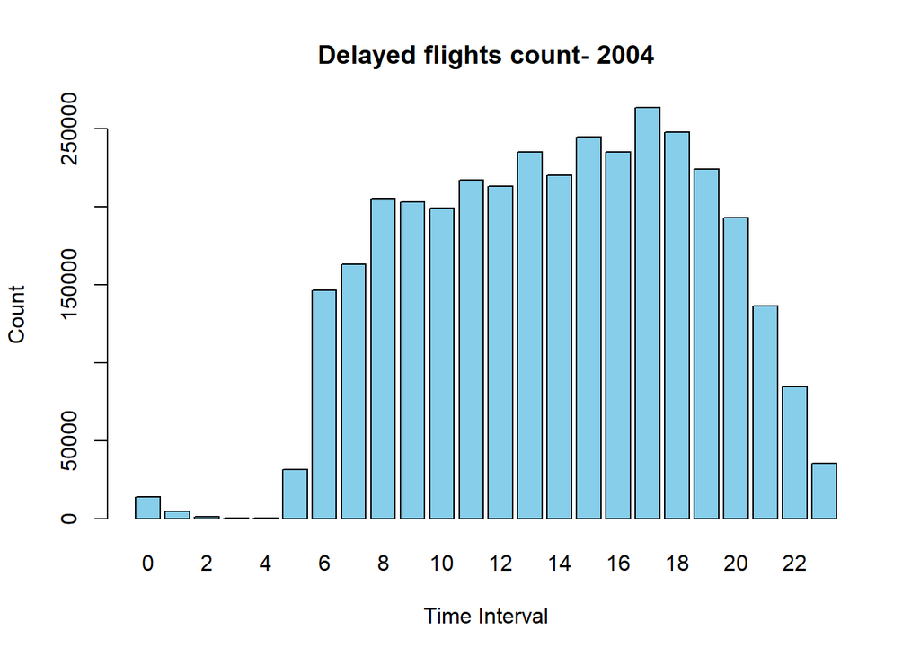

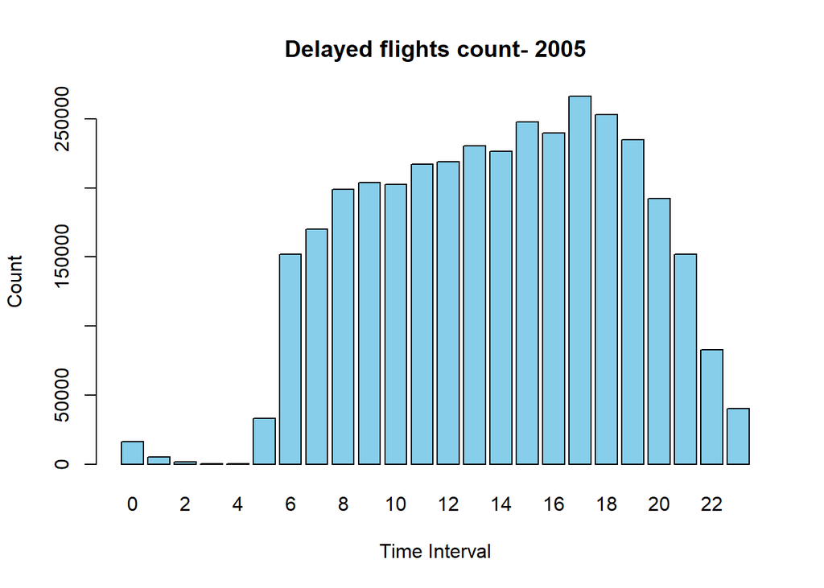

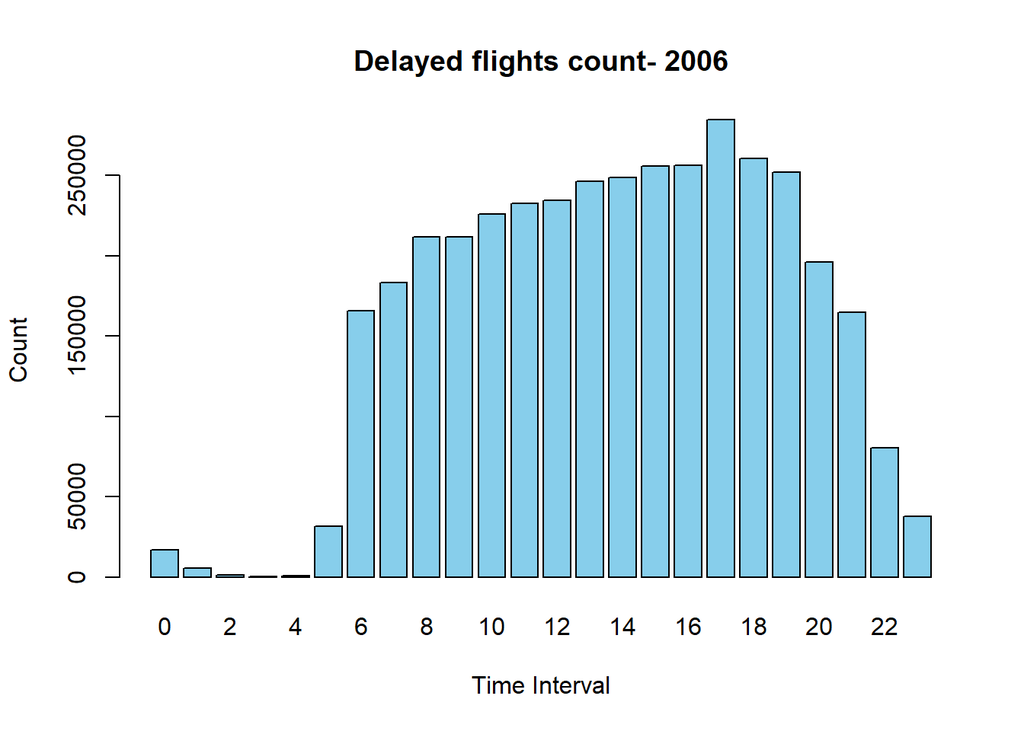

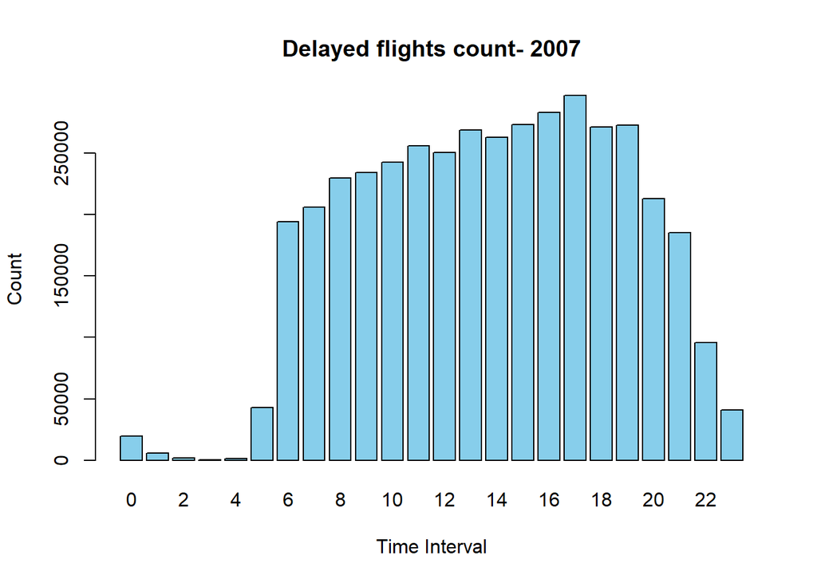

```r
for(year in 1998:2007){
delayed_hour_df<-delayed_df %>%
  filter(Year == year) %>%
  mutate(TimeInterval = cut(DepTime, breaks = seq(0, 2400, by = 100), include.lowest = TRUE)) %>%
  group_by(TimeInterval) %>%
  summarise(count = n())

  delayed_hour_df <- merge(all_intervals, delayed_hour_df, by = "TimeInterval", all.x = TRUE, sort = FALSE)
  delayed_hour_df$count[is.na(delayed_hour_df$count)] <- 0


barplot(height = delayed_hour_df$count, names.arg = c("0","1", "2", "3", "4", "5", "6", "7", "8", "9", "10", "11", "12", "13", "14", "15", "16", "17", "18", "19", "20", "21", "22", "23"),
        xlab = "Time Interval",
        ylab = "Count",
        col = "skyblue",
        main = paste("Delayed flights count-", year)
        )}
```

Here we do a similar for loop as above except that we calculate a new variable prob_delayed which is the probability of delay which is found by taking the count of delayed flight for each time interval and dividing them by the total flights in each time interval.

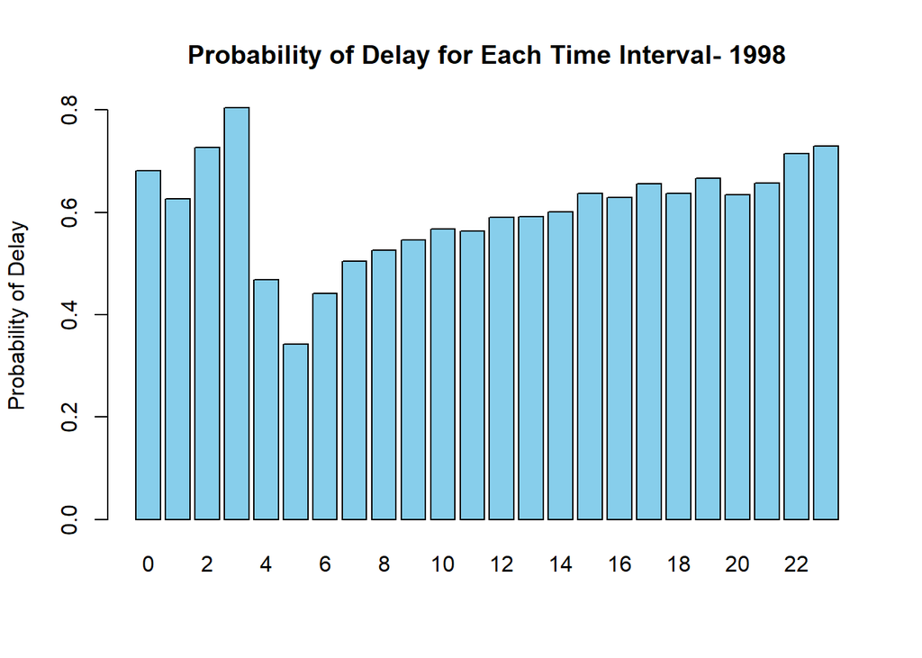

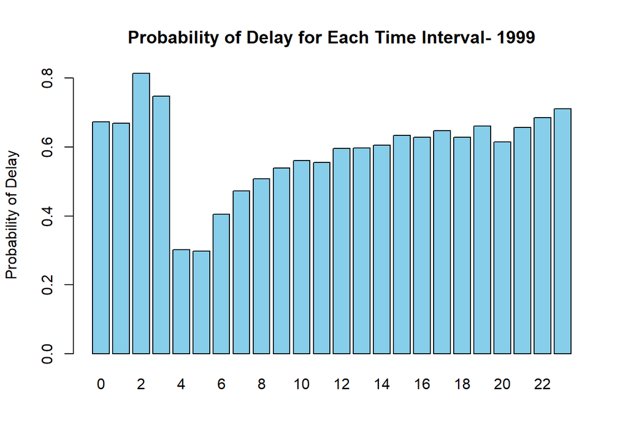

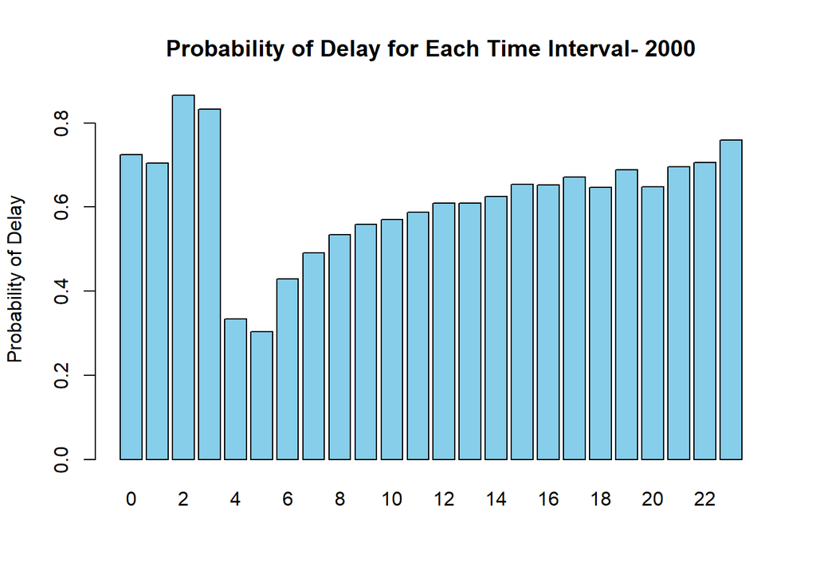

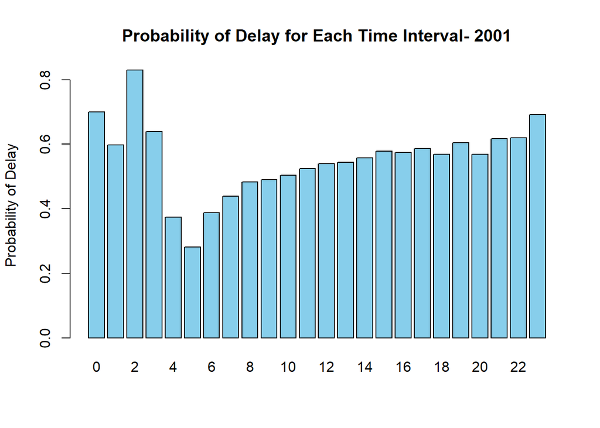

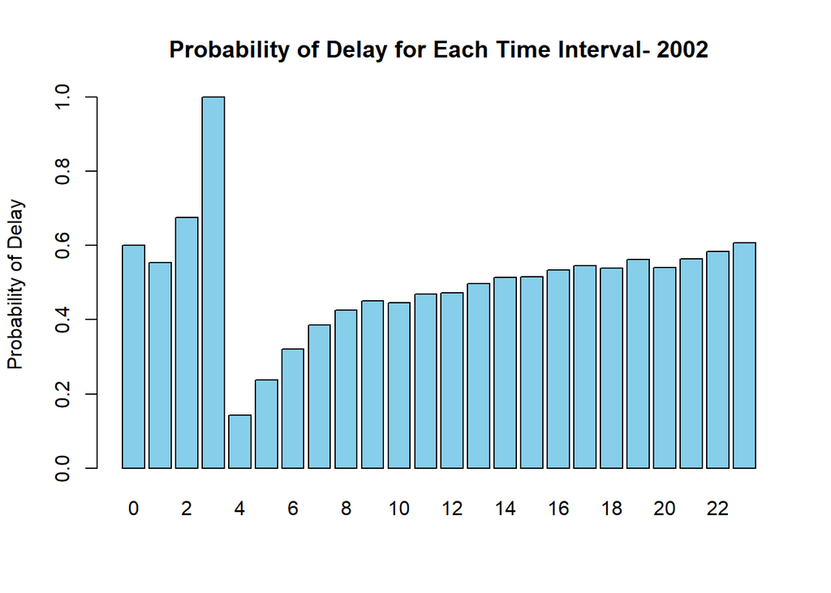

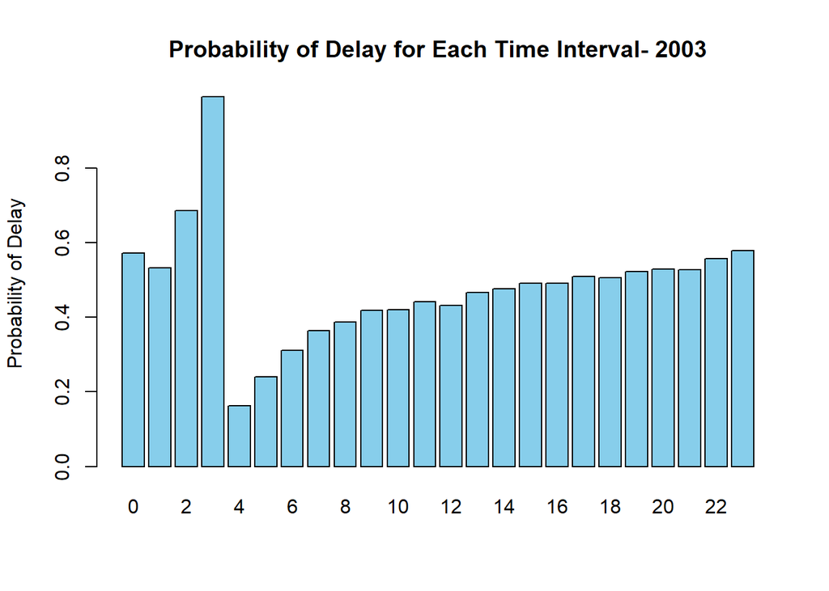

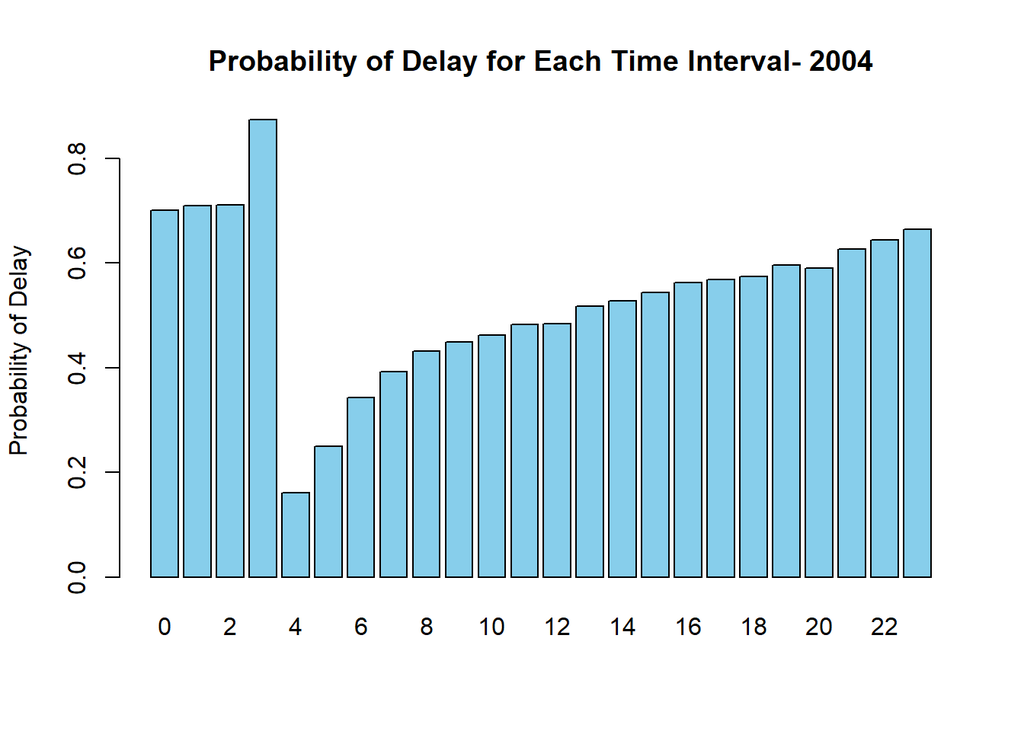

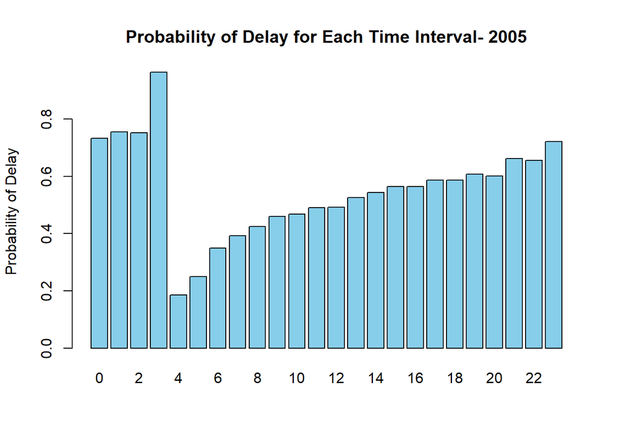

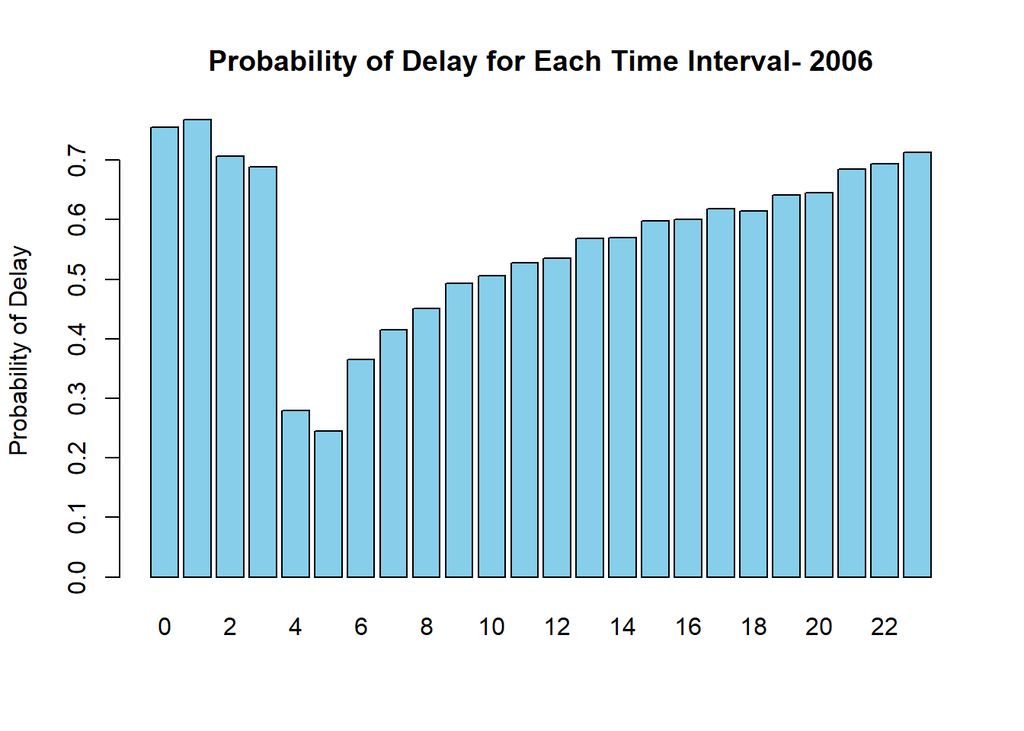

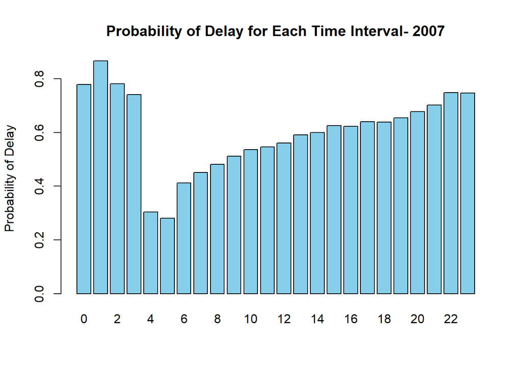

```r
for(year in 1998:2007){
combined_plane_df<- combined_plane %>%
  filter(Year == year)%>%
  mutate(TimeInterval = cut(DepTime, breaks = seq(0, 2400, by = 100), include.lowest = TRUE,include.highest=FALSE)) %>%
  group_by(TimeInterval) %>%
  summarise(count = n())

delayed_hour_prob<-delayed_df %>%
  filter(Year == year) %>%
  mutate(TimeInterval = cut(DepTime, breaks = seq(0, 2400, by = 100), include.lowest = TRUE)) %>%
  group_by(TimeInterval) %>%
  summarise(count = n())

  delayed_hour_prob <- merge(all_intervals, delayed_hour_prob, by = "TimeInterval", all.x = TRUE, sort = FALSE)
  delayed_hour_prob$count[is.na(delayed_hour_prob$count)] <- 0

prob_delayed <- delayed_hour_prob$count/combined_plane_df$count #probability of delay calculation

barplot(prob_delayed,
        names.arg = c("0","1", "2", "3", "4", "5", "6", "7", "8", "9", "10", "11", "12", "13", "14", "15", "16", "17", "18", "19", "20", "21", "22", "23"),
        ylab = "Probability of Delay",
        col = "skyblue",
        main = paste("Probability of Delay for Each Time Interval-",year))}
```

## reading of plane_data

Here we read csv file plane-data.csv and check for entries in year column for missing ,None or 0000 inputs and we remove these rows as they are invalid as well as keeping only tailnum and year variables. We then reset the index of plane_data.We can see that we end up with 4332 observations of 2 variables

```r
plane_data<-read.csv("plane-data.csv",header = TRUE)

plane_data <- plane_data[!(plane_data$year %in% c("", "None","0000")), c('tailnum', 'year')] #remove entries with invalid values and keep only tailnum and year columns
row.names(plane_data)<- NULL #reset index
```

## join dataframes together and create new variable age

Here we perform a inner join of combined_plane which contains data of all flights with plane_data by tailnum, we then create a new variable Age for this new dataframe by making use of the mutate() function with Age being calculated by taking the Year of the flight minus the year of plane manufactured given in plane_data. We then filter out data with age <0 as these are invalid entries. We can see from age_df we have 32376911 instead of 61615503 entries which is due to us removing data that has age <0 and data that does not have a tailnum that matches.

```r
combined_plane_new<-combined_plane %>% inner_join(plane_data,by = c("TailNum" = "tailnum"))

age_df<- combined_plane_new %>%
  mutate(Age= combined_plane_new$Year- as.integer(combined_plane_new$year))%>% #calculation of age variable
  filter(Age>=0) #remove invalid entries of age <0
```

## plotting graphs age distribution of planes and breaking them up into groups

Here we make use of ggplot2 package to plot a histogram of the age distribution of the flights at the same time we subset the dataframe by only keeping entries with arrival delay or departure delay more than 0. We can see from the data that age_delayed_df has 17594842 observations.

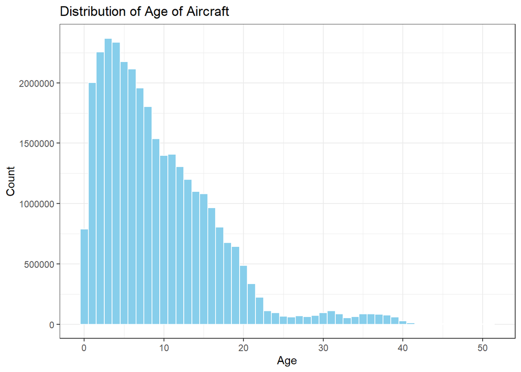

```r
ggplot(age_df ,aes(x=age_df$Age)) +geom_histogram(binwidth = 1, fill= "skyblue", color="white") +
  labs(title = "Distribution of Age of Aircraft",x="Age",y="Count")+
  theme_bw() #plot
```

```r
age_delayed_df <-subset(age_df, ArrDelay >0 | DepDelay >0) #keep only rows with poitive arrdelay or positive depdelay
```

we can see that from age 22 onwards there is a small sample size with number of aircraft age 23 half of that of 22

## creating variables of avg arrival and depature delay and plotting them by year for both age groups from 0 to 22 and for all ages

Here we first create an empty list to store all the plots generated from the for loop below. A for loop is then run for years from 1998 to 2007 plotting 4 different scatter plots of average arrival delay and average depature delay, for each one plot is plotted for all ages from 0-51 and on plot is plotted for ages only from 0 to 22, each plot has a linear regression line plotted to determine the correlation.The coefficient of the slope of the line is also determined and annotated on the top of each scatter plot.

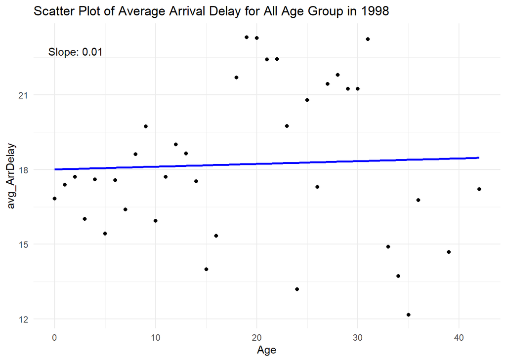

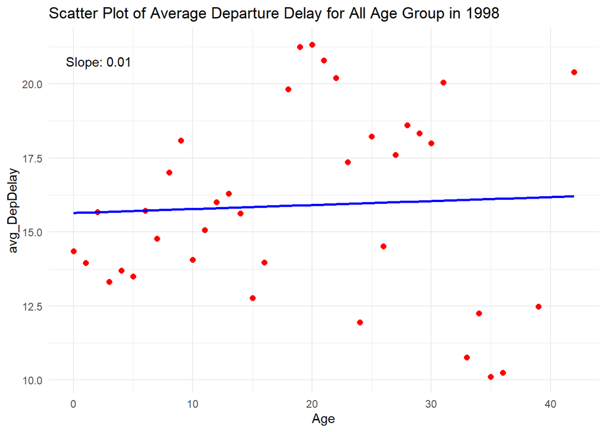

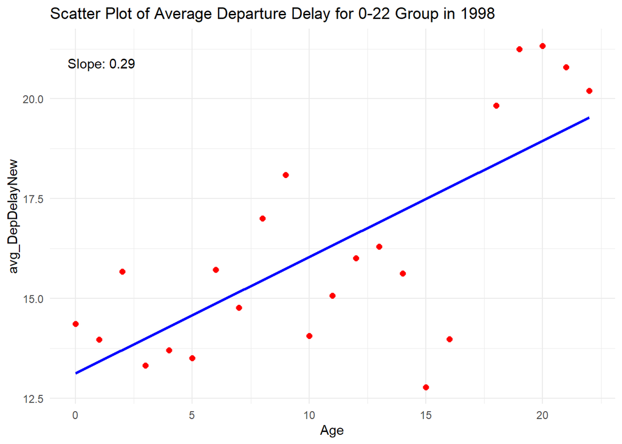

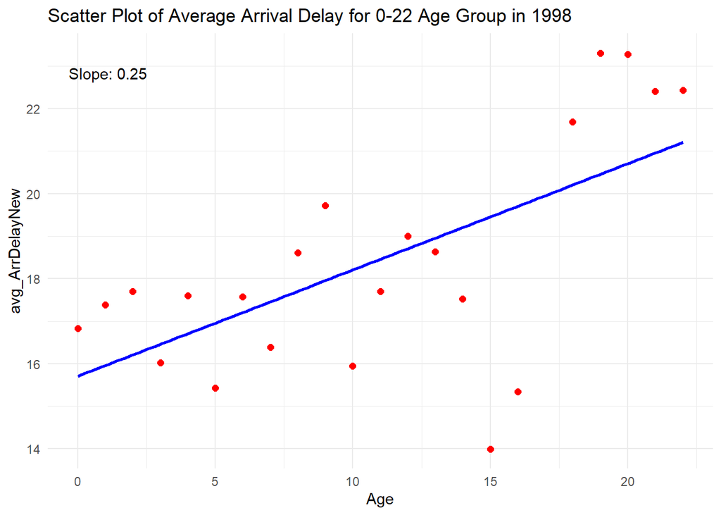

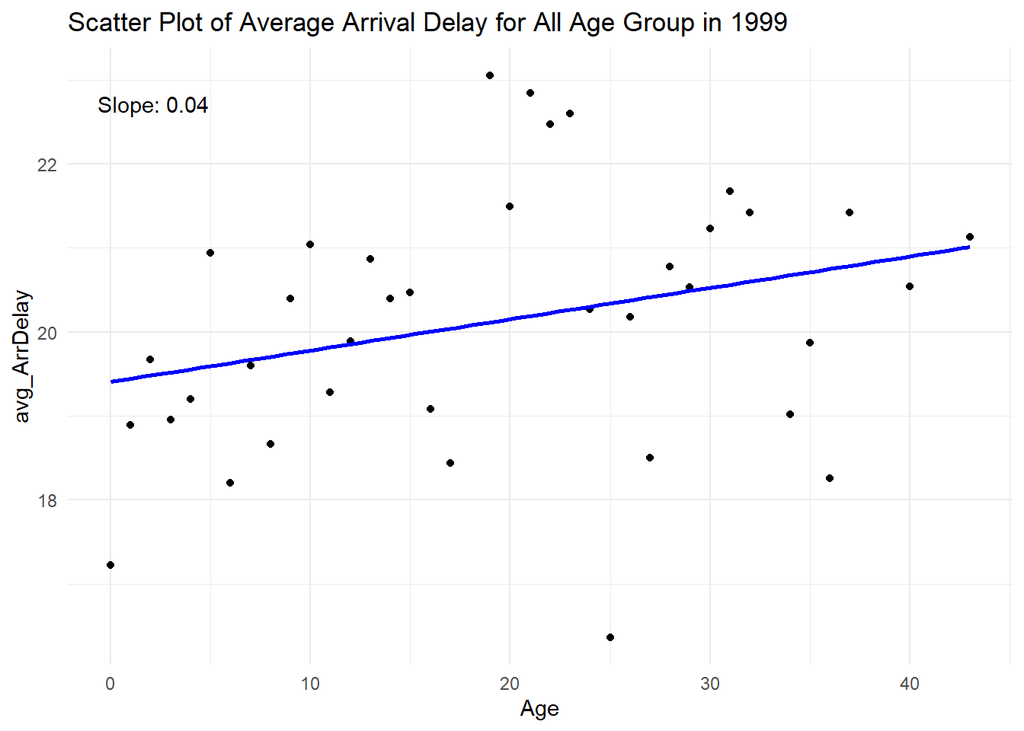

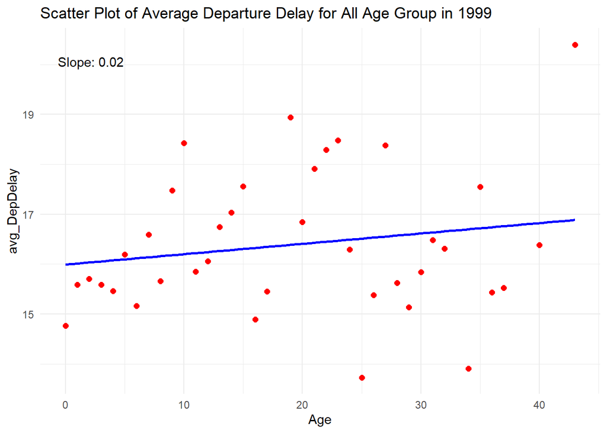

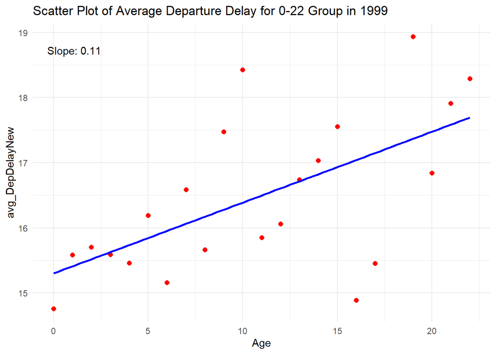

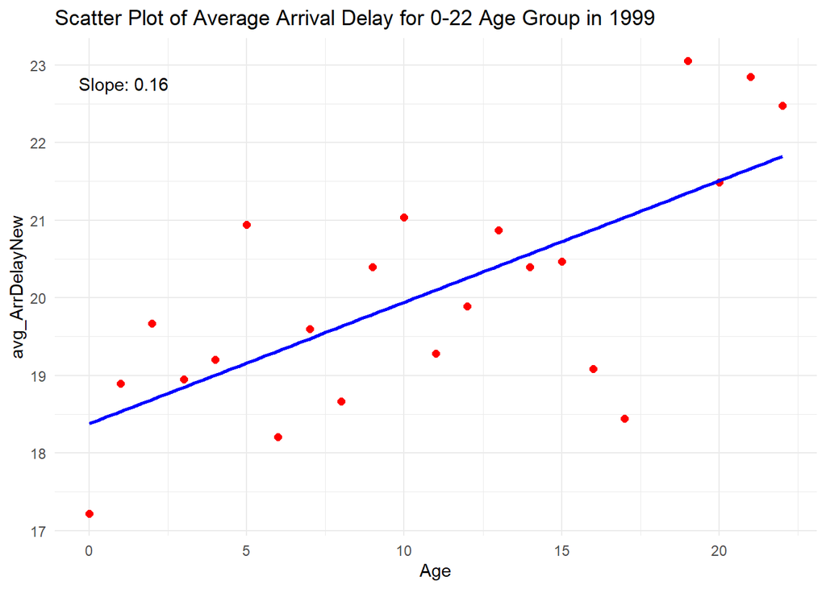

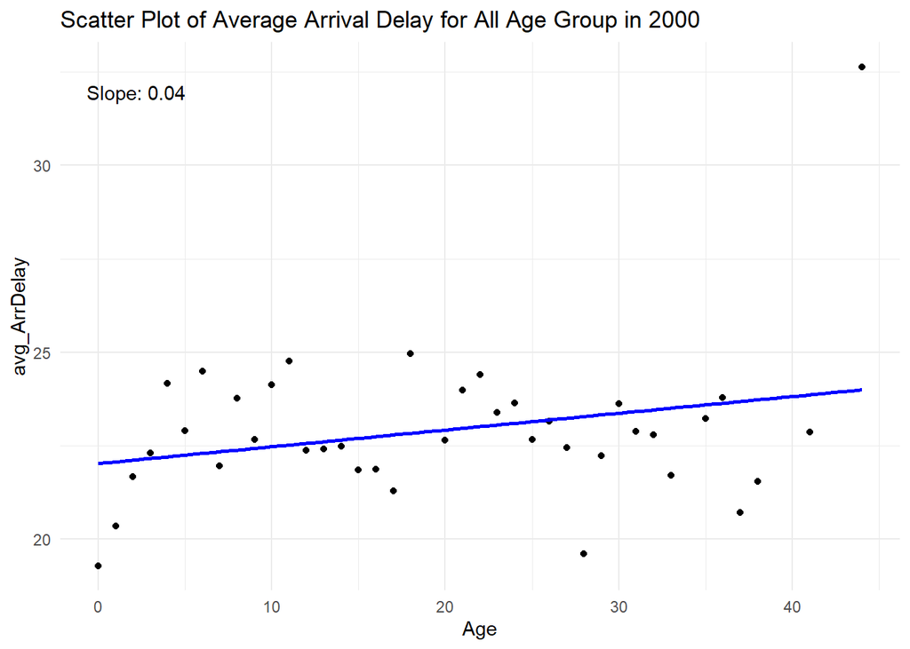

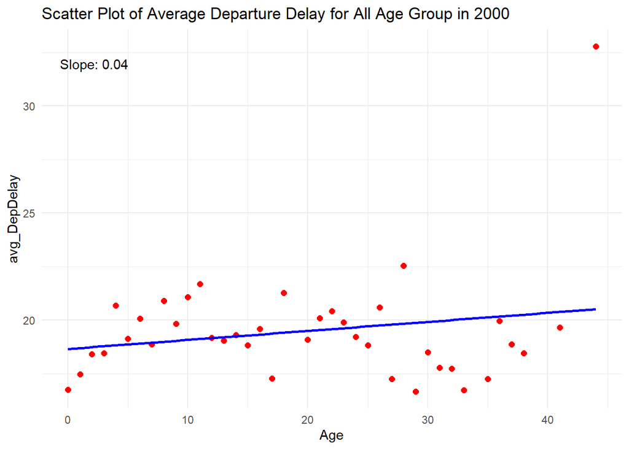

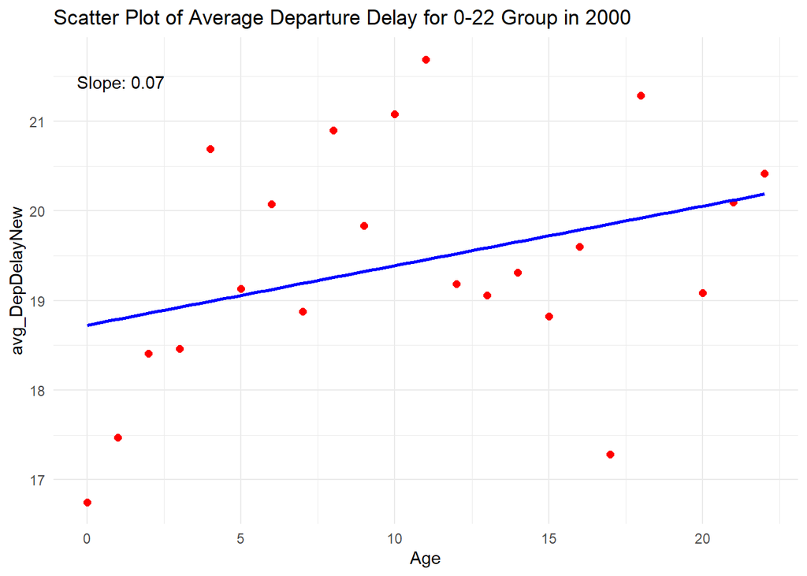

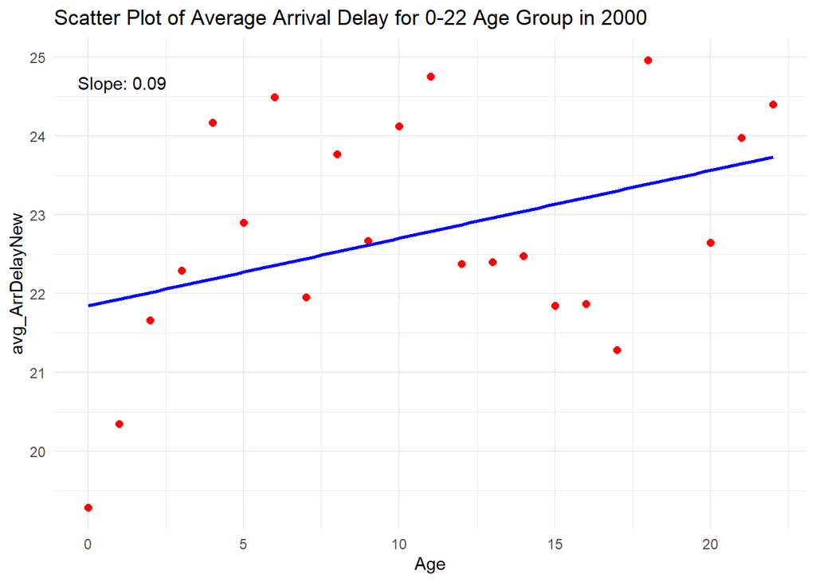

[28 more figures not shown]

```r
plots_list <- list()
for (years in 1998:2007) {
  avg_arr_delay <- age_delayed_df %>%
    filter(Year == years) %>%
    group_by(Age) %>%
    summarise(avg_ArrDelay = mean(ArrDelay, na.rm = TRUE))

  plot<- ggplot(avg_arr_delay, aes(x = Age, y = avg_ArrDelay)) +
    geom_point() +
    geom_smooth(method = "lm", se = FALSE, color = "blue") +
    ggtitle(paste("Scatter Plot of Average Arrival Delay for All Age Group in", years)) +
    theme_minimal()+
   annotate("text", x = min(avg_arr_delay$Age) + 0.05 * diff(range(avg_arr_delay$Age)),
             y = max(avg_arr_delay$avg_ArrDelay) - 0.05 * diff(range(avg_arr_delay$avg_ArrDelay)),
             label = paste("Slope:", round(coef(summary(lm(avg_ArrDelay ~ Age, data = avg_arr_delay)))[2,1], 2)))


  avg_Dep_delay <- age_delayed_df %>%
    filter(Year == years) %>%
    group_by(Age) %>%
    summarise(avg_DepDelay = mean(DepDelay, na.rm = TRUE))

  plot1<- ggplot(avg_Dep_delay, aes(x = Age, y = avg_DepDelay)) +
    geom_point(color="red", size = 2) +
    geom_smooth(method = "lm", se = FALSE, color = "blue") +
    ggtitle(paste("Scatter Plot of Average Departure Delay for All Age Group in", years)) +
    theme_minimal()+
    annotate("text", x = min(avg_Dep_delay$Age) + 0.05 * diff(range(avg_Dep_delay$Age)),
             y = max(avg_Dep_delay$avg_DepDelay) - 0.05 * diff(range(avg_Dep_delay$avg_DepDelay)),
             label = paste("Slope:", round(coef(summary(lm(avg_DepDelay ~ Age, data = avg_Dep_delay)))[2,1], 2)))


  avg_Dep_delay_new <- age_delayed_df %>%
    filter(Year == years,  Age >= 0, Age <= 22) %>%
    group_by(Age) %>%
    summarise(avg_DepDelayNew = mean(DepDelay, na.rm = TRUE))

  plot2<- ggplot(avg_Dep_delay_new, aes(x = Age, y = avg_DepDelayNew)) +
    geom_point(color="red", size = 2) +
    geom_smooth(method = "lm", se = FALSE, color = "blue") +
    ggtitle(paste("Scatter Plot of Average Departure Delay for 0-22 Group in", years)) +
    theme_minimal()+
    annotate("text", x = min(avg_Dep_delay_new$Age) + 0.05 * diff(range(avg_Dep_delay_new$Age)),
             y = max(avg_Dep_delay_new$avg_DepDelayNew) - 0.05 * diff(range(avg_Dep_delay_new$avg_DepDelayNew)),
             label = paste("Slope:", round(coef(summary(lm(avg_DepDelayNew ~ Age, data = avg_Dep_delay_new)))[2,1], 2)))


  avg_Arr_delay_new <- age_delayed_df %>%
    filter(Year == years,  Age >= 0, Age <= 22) %>%
    group_by(Age) %>%
    summarise(avg_ArrDelayNew = mean(ArrDelay, na.rm = TRUE))

  plot3<- ggplot(avg_Arr_delay_new, aes(x = Age, y = avg_ArrDelayNew)) +
    geom_point(color="red", size = 2) +
    geom_smooth(method = "lm", se = FALSE, color = "blue") +
    ggtitle(paste("Scatter Plot of Average Arrival Delay for 0-22 Age Group in", years)) +
    theme_minimal()+
    annotate("text", x = min(avg_Arr_delay_new$Age) + 0.05 * diff(range(avg_Arr_delay_new$Age)),
             y = max(avg_Arr_delay_new$avg_ArrDelayNew) - 0.05 * diff(range(avg_Arr_delay_new$avg_ArrDelayNew)),
             label = paste("Slope:", round(coef(summary(lm(avg_ArrDelayNew ~ Age, data = avg_Arr_delay_new)))[2,1], 2)))

  plots_list[[years]] <- list(plot, plot1, plot2, plot3)
}
for (plots in plots_list) {
  for (plot in plots) {
    if (!is.null(plot)) {
      print(plot)
    }
  }
}
```

We can observe that for year 1998-2002 there is a positive correlation for age and average arrival and departure delays for both all age groups and for ages 0-22,for year 2003 and 2004 there is a positive correlation for arrival delay for all ages but a negative correlation for departure delay for all ages.However, looking at the average departure delay for ages 0-22 there is a positive correlation hence we can still determine that there is a postive correlation between ages and delays for these 2 years. For years 2005, there is a positive correlation for arrival delays for all ages and a negatve correlation for departure delay for all ages.Looking at the 0-22 plots, there is a negative correlation for arrival delays and no correlation for departure delays, hence we can determine that there is a negative correlation for ages and delays for that year. For year 2006, there is a negative correlation for all 4 plots indicating a strong evidence that there is a negative correlation between ages and delays for that year.For year 2007 there is a positive correlation between average arrival and departure delays for all age groups but for 0-22 there is a negative correlation. Hence since 0-22 has a much larger sample size we can determine that there is a negative correlation for that year. ## Part B

## install and load mlr3 packages

Here we check if mlr3 packages are already installed and install the packages if they are not, we then load in the mlr3 packages installed.

```r
if (!"mlr3" %in% rownames(installed.packages())) {
  install.packages("mlr3")
}
if (!"mlr3learners" %in% rownames(installed.packages())) {
  install.packages("mlr3learners")
}
if (!"mlr3pipelines" %in% rownames(installed.packages())) {
  install.packages("mlr3pipelines")
}
if (!"mlr3viz" %in% rownames(installed.packages())) {
  install.packages("mlr3viz") }
library(mlr3)
library(mlr3learners)
library(mlr3pipelines)
library(mlr3viz)
```

## read all csv files from 1998 to 2007 .csv

```r
Full_df<- list.files(pattern = "(199[8-9]|200[0-7])\\.csv$") %>%
  map_df(~fread(.))
```

## subsetting and factoring

Here we subset the data to keep only specific variables, and convert Diverted variables from an integer to a factor , looking at the data ml2_df has 7 variables with Diverted as a factor with 2 levels.

```r
ml2_df <- Full_df[, c('Diverted','Year','Month','DayofMonth','CRSDepTime','CRSArrTime','Distance'),with= FALSE] #subset ml2_df to keep only certain columns
ml2_df$Diverted <- factor(ml2_df$Diverted)
```

Here unused dataframes are removed and gc() is runned to free up memory.

```r
remove(Full_df) #save memory
gc()
```

```
##              used    (Mb) gc trigger    (Mb)   max used    (Mb)
## Ncells    2647763   141.5    5847988   312.4    5847988   312.4
## Vcells 1772267159 13521.4 5614631925 42836.3 5597365203 42704.6
```

## for loop to run mlr3 logistic regression

Here first a list is created to store our coefficients obtained later on, then we make use of a for loop to run the logistic regression model for each year, we first filter the dataframe into the specific year and create a task and define the dependent variable, we then select the independent variables and select our measure. A train test split is done to split the data into two portions on for training and one for testing, we create our pipeline operation using imputemean and we set up the graph learner and train our model. After training we test our model and print our classification error score. We then obtain the coefficients of the independent variables and store them in a list.

```r
variable_names <- c('Month', 'DayofMonth', 'CRSDepTime', 'CRSArrTime', 'Distance')

# Predefine the columns of coefficients_list
coefficients_list <- lapply(setNames(rep(list(NA), length(variable_names)), variable_names), function(x) rep(x, length(1998:2007)))

for(years in 1998:2007) {
  # Subset the dataset for the current year
  ml2_df_year <- ml2_df %>%
    filter(Year == years)

  # Create a task for classification
  task_id <- paste("ml2_df_", years, sep = "")
  task <- TaskClassif$new(id = task_id, backend = ml2_df_year, target = 'Diverted')
  task$select(c('Month', 'DayofMonth', 'CRSDepTime', 'CRSArrTime', 'Distance'))

  # Split data into training and testing sets
  row_no <- nrow(ml2_df_year)
  train_set <- sample(row_no, round(0.5 * row_no))
  test_set <- setdiff(1:row_no, train_set)

  # Define the logistic regression learner
  lr_learner <- lrn("classif.log_reg")
  gc_lr <- po('imputemean') %>>% po(lr_learner)
  graph_lr <- GraphLearner$new(gc_lr)

  # Train the logistic regression model
  graph_lr$train(task, row_ids = train_set)
  score_df<-graph_lr$predict(task, row_ids = test_set)$score()
  print(score_df)
  # Get coefficients
  coefficients <- graph_lr$model$classif.log_reg$model$coefficients
  # Store coefficients for each variable
  for (var in names(coefficients)) {
    coefficients_list[[var]][years - 1997] <- coefficients[var]
  }
}
```

```
##  classif.ce
## 0.002468094
##  classif.ce
## 0.002443973
##  classif.ce
## 0.002508514
##  classif.ce
## 0.002169986
## classif.ce
##  0.0015662
##  classif.ce
## 0.001756327
##  classif.ce
## 0.001965138
##  classif.ce
## 0.001943255
##  classif.ce
## 0.002267457
##  classif.ce
## 0.002307998
```

## plotting of coefficients against year for each variable

Using the list we obtained we plot a graph of coefficients against year for each of the variable using ggplot2.

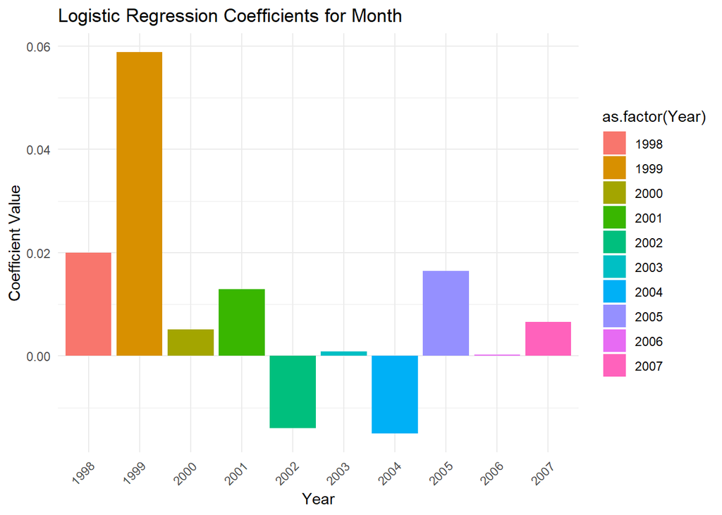

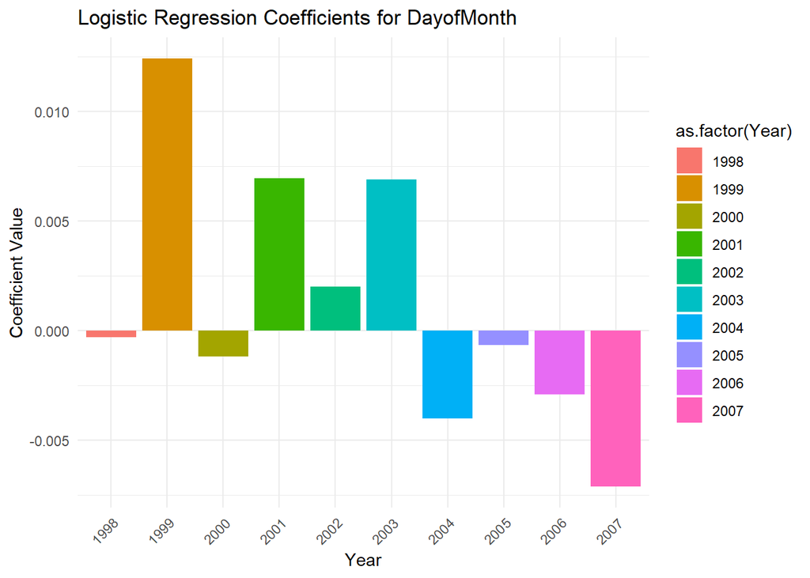

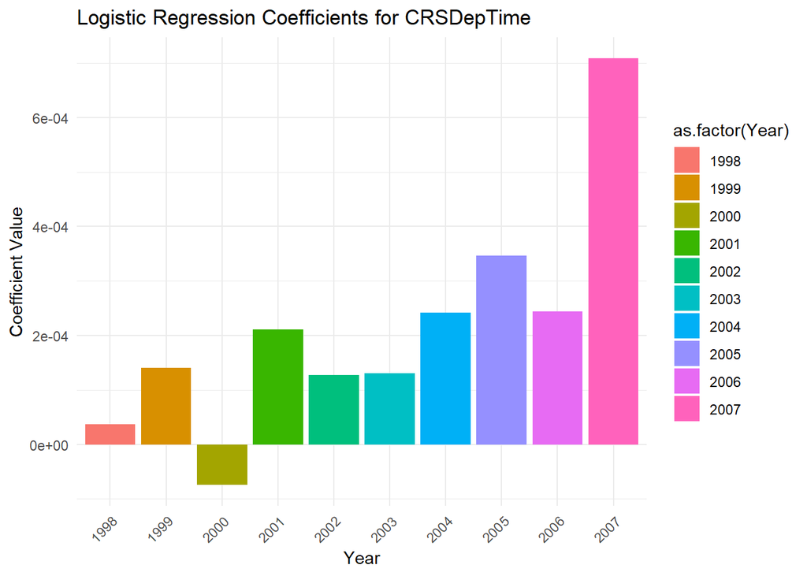

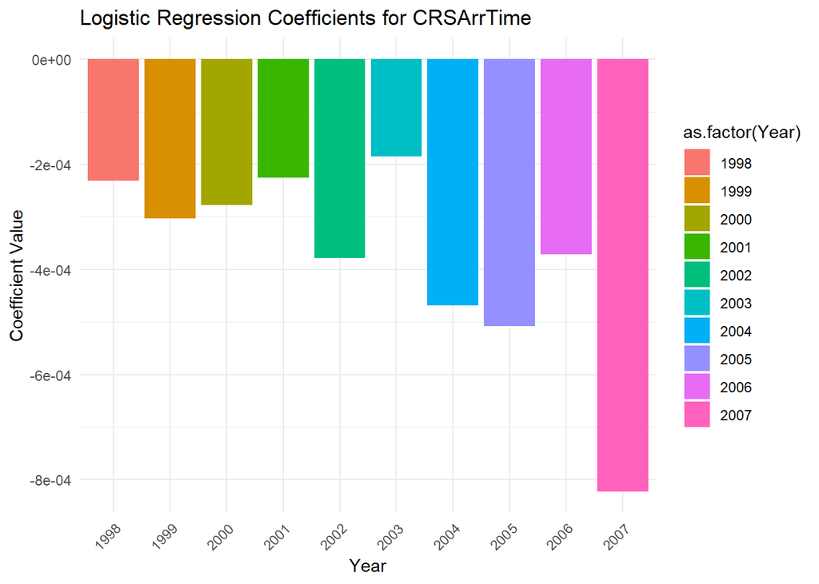

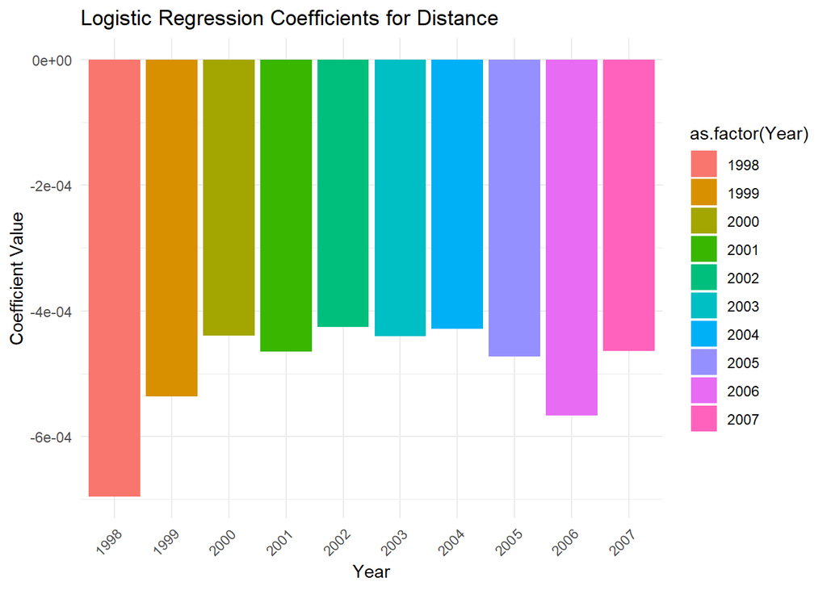

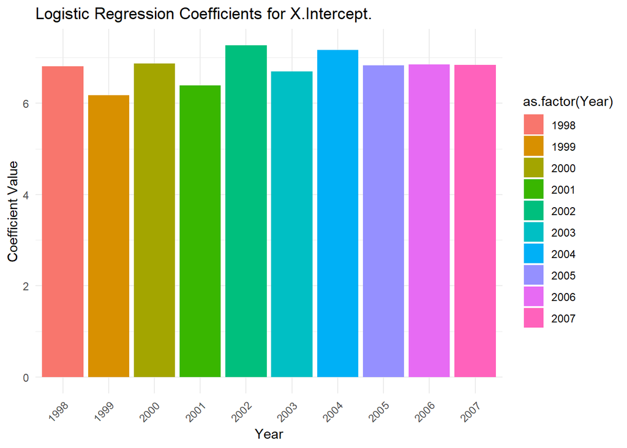

```r
coefficients_df <- as.data.frame(coefficients_list)
coefficients_df$Year <- rep(1998:2007, each = nrow(coefficients_df) / length(1998:2007))
coefficients_df_long <- tidyr::pivot_longer(coefficients_df, cols = -Year, names_to = "Variable", values_to = "Coefficient")
# Plot bar plot of each variable comparing across the years
plots <- lapply(unique(coefficients_df_long$Variable), function(variable) {
  ggplot(subset(coefficients_df_long, Variable == variable), aes(x = as.factor(Year), y = Coefficient, fill = as.factor(Year))) +
    geom_bar(stat = "identity", position = "dodge") +
    labs(title = paste("Logistic Regression Coefficients for", variable),
         x = "Year",
         y = "Coefficient Value") +
    theme_minimal() +
    theme(axis.text.x = element_text(angle = 45, hjust = 1))
})
plots
```